# Gaze Synchrony — End-to-End Demo

*This analysis is adapted from my MSc thesis project at Goldsmiths, UoL with Neurolive @ UCL. A full version is available upon request.*

The work investigates **eye-movement synchrony across participants**, focusing on how correlations emerge at different **time-scales**. This is motivated by theories of **cortical time-scale architecture** and temporal integration in perception and social cognition, as outlined in:

- Barrett (2017) — theories of emotion and predictive brain architecture
- Kiebel, Daunizeau, & Friston (2008) — a hierarchy of time-scales and the brain
- Decety & Jackson (2004) — functional architecture of human empathy

By analyzing synchrony in both **short windows (5s)** and **longer windows (30s)**, this project tests how alignment of attention unfolds across multiple temporal levels, linking experimental data with these theoretical frameworks. In this demo, due to the small sample data size, synchrony is analyzed here in **1s windows** and **5s windows**.

The notebook then demonstrates the full technical pipeline:

[output not shown]

```python
from pathlib import Path
import sys, subprocess
import pandas as pd
import numpy as np

REPO_ROOT = Path(".").resolve().parents[0]
SRC = REPO_ROOT / "src"
DATA_RAW = REPO_ROOT / "data" / "raw" / "demo"
DATA_PROC = REPO_ROOT / "data" / "processed" / "demo"

#print("Repo root:", REPO_ROOT)
#print("Scripts exist:", (SRC / "preprocess.py").exists(), (SRC / "positioning-3d.py").exists(), (SRC / "synchrony.py").exists())
#print("Raw demo dir:", DATA_RAW.exists(), "Processed demo dir:", DATA_PROC.exists())

def run_script(name, *args):
    """Run a Python script from src/ with optional CLI args."""
    cmd = [sys.executable, str(SRC / name), *map(str, args)]
    print("→ Running:", " ".join(cmd))
    res = subprocess.run(cmd, cwd=REPO_ROOT)
    if res.returncode != 0:
        raise RuntimeError(f"{name} failed with code {res.returncode}")
```

## 1) Preprocess (resample to 50 Hz & align starts)

Reads each `participant_*` in `data/raw/demo/` and writes `imu_50Hz.csv`, `gaze_50Hz.csv`, `video_timestamps.csv` to the corresponding folder in `data/processed/demo/participant_*`.

```python
run_script("preprocess.py")
```

```
→ Running: /opt/anaconda3/bin/python /Users/jnares/Desktop/Important Docs/Coding Portfolio/gaze-synchrony-3d-thesis/src/preprocess.py

→ Processing Participant_A
✓ Wrote /Users/jnares/Desktop/Important Docs/Coding Portfolio/gaze-synchrony-3d-thesis/data/processed/demo/Participant_A/imu_50Hz.csv and /Users/jnares/Desktop/Important Docs/Coding Portfolio/gaze-synchrony-3d-thesis/data/processed/demo/Participant_A/gaze_50Hz.csv
✓ Wrote /Users/jnares/Desktop/Important Docs/Coding Portfolio/gaze-synchrony-3d-thesis/data/processed/demo/Participant_A/video_timestamps.csv

→ Processing Participant_B
✓ Wrote /Users/jnares/Desktop/Important Docs/Coding Portfolio/gaze-synchrony-3d-thesis/data/processed/demo/Participant_B/imu_50Hz.csv and /Users/jnares/Desktop/Important Docs/Coding Portfolio/gaze-synchrony-3d-thesis/data/processed/demo/Participant_B/gaze_50Hz.csv
✓ Wrote /Users/jnares/Desktop/Important Docs/Coding Portfolio/gaze-synchrony-3d-thesis/data/processed/demo/Participant_B/video_timestamps.csv

→ Processing Participant_D
✓ Wrote /Users/jnares/Desktop/Important Docs/Coding Portfolio/gaze-synchrony-3d-thesis/data/processed/demo/Participant_D/imu_50Hz.csv and /Users/jnares/Desktop/Important Docs/Coding Portfolio/gaze-synchrony-3d-thesis/data/processed/demo/Participant_D/gaze_50Hz.csv
✓ Wrote /Users/jnares/Desktop/Important Docs/Coding Portfolio/gaze-synchrony-3d-thesis/data/processed/demo/Participant_D/video_timestamps.csv
```

## 2) 3D Positioning

Uses the 50 Hz data + `data/raw/layout/Stage_Layout_Coordinates.csv` to compute `eye_in_world.csv` per participant.

```python
run_script("positioning-3d.py", "--export-heading")
```

```
→ Running: /opt/anaconda3/bin/python /Users/jnares/Desktop/Important Docs/Coding Portfolio/gaze-synchrony-3d-thesis/src/positioning-3d.py --export-heading

→ Positioning Participant_A (ID=A)
  ✓ Wrote /Users/jnares/Desktop/Important Docs/Coding Portfolio/gaze-synchrony-3d-thesis/data/processed/demo/Participant_A/eye_in_world.csv
  • Wrote /Users/jnares/Desktop/Important Docs/Coding Portfolio/gaze-synchrony-3d-thesis/data/processed/demo/Participant_A/heading_50Hz.csv

→ Positioning Participant_B (ID=B)
  ✓ Wrote /Users/jnares/Desktop/Important Docs/Coding Portfolio/gaze-synchrony-3d-thesis/data/processed/demo/Participant_B/eye_in_world.csv
  • Wrote /Users/jnares/Desktop/Important Docs/Coding Portfolio/gaze-synchrony-3d-thesis/data/processed/demo/Participant_B/heading_50Hz.csv

→ Positioning Participant_D (ID=D)
  ✓ Wrote /Users/jnares/Desktop/Important Docs/Coding Portfolio/gaze-synchrony-3d-thesis/data/processed/demo/Participant_D/eye_in_world.csv
  • Wrote /Users/jnares/Desktop/Important Docs/Coding Portfolio/gaze-synchrony-3d-thesis/data/processed/demo/Participant_D/heading_50Hz.csv
```

## 3) Synchrony (Pairwise & Individual → Group)

```python
run_script("synchrony.py")
```

```
→ Running: /opt/anaconda3/bin/python /Users/jnares/Desktop/Important Docs/Coding Portfolio/gaze-synchrony-3d-thesis/src/synchrony.py
/Users/jnares/Desktop/Important Docs/Coding Portfolio/gaze-synchrony-3d-thesis/data/processed/demo
✓ Saved pairwise sync (1s): /Users/jnares/Desktop/Important Docs/Coding Portfolio/gaze-synchrony-3d-thesis/data/processed/demo/pairwise_sync/1s/pairwise_group_sync.csv
✓ Saved indiv→group sync (1s): /Users/jnares/Desktop/Important Docs/Coding Portfolio/gaze-synchrony-3d-thesis/data/processed/demo/indiv_to_group_sync/1s/indiv_vs_group_sync.csv
✓ Saved pairwise sync (5s): /Users/jnares/Desktop/Important Docs/Coding Portfolio/gaze-synchrony-3d-thesis/data/processed/demo/pairwise_sync/5s/pairwise_group_sync.csv
✓ Saved indiv→group sync (5s): /Users/jnares/Desktop/Important Docs/Coding Portfolio/gaze-synchrony-3d-thesis/data/processed/demo/indiv_to_group_sync/5s/indiv_vs_group_sync.csv
```

## 4) Quick peek at participants and outputs

```python
parts = [d for d in DATA_PROC.iterdir() if d.is_dir() and d.name.lower().startswith("participant_")]
print("Participants:", [p.name for p in parts])
```

```
Participants: ['Participant_A', 'Participant_B', 'Participant_D']
```

### 4a) Visualize 3D Trajectory (one participant)

Simple scatter plot of `eye_in_world.csv`. Pick any `participant_*`.

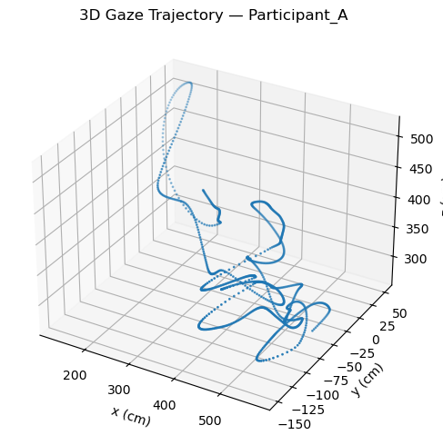

```python
import matplotlib.pyplot as plt
from mpl_toolkits.mplot3d import Axes3D  # noqa: F401

assert parts, "No processed participants found."
p0 = parts[0]
df_eye = pd.read_csv(p0 / "eye_in_world.csv")

fig = plt.figure(figsize=(7, 5))
ax = fig.add_subplot(111, projection="3d")
ax.scatter(df_eye["x"], df_eye["y"], df_eye["z"], s=1)
ax.set_xlabel("x (cm)")
ax.set_ylabel("y (cm)")
ax.set_zlabel("z (cm)")
ax.set_title(f"3D Gaze Trajectory — {p0.name}")
plt.tight_layout()
plt.show()
```

### 4b) Plot Pairwise Synchrony (1s & 5s)

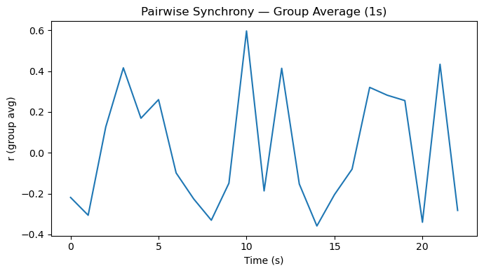

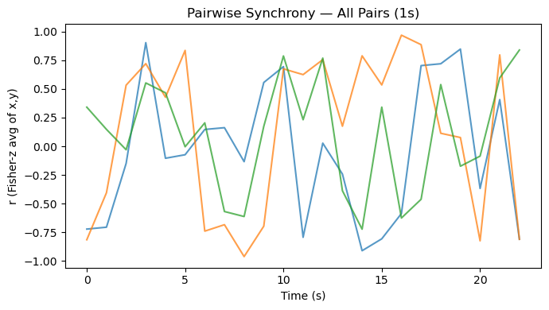

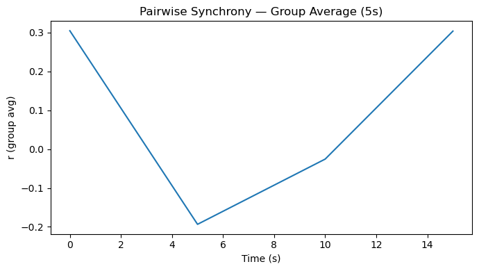

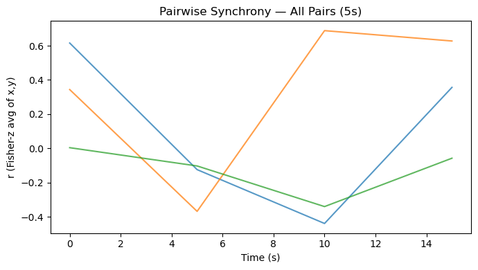

```python
def plot_pairwise(window="1s"):
    csv_path = DATA_PROC / "pairwise_sync" / window / "pairwise_group_sync.csv"
    dfp = pd.read_csv(csv_path)
    time = dfp["time_s"]

    # Group average
    plt.figure(figsize=(7, 4))
    plt.plot(time, dfp["GroupAverage"])
    plt.xlabel("Time (s)")
    plt.ylabel("r (group avg)")
    plt.title(f"Pairwise Synchrony — Group Average ({window})")
    plt.tight_layout()
    plt.show()

    # All pairs
    pair_cols = [c for c in dfp.columns if c.startswith("PairID_")]
    plt.figure(figsize=(7, 4))
    for c in pair_cols:
        plt.plot(time, dfp[c], alpha=0.75)
    plt.xlabel("Time (s)")
    plt.ylabel("r (Fisher-z avg of x,y)")
    plt.title(f"Pairwise Synchrony — All Pairs ({window})")
    plt.tight_layout()
    plt.show()

plot_pairwise("1s")
plot_pairwise("5s")
```

### 4c) Plot Individual-to-Group Synchrony (1s & 5s)

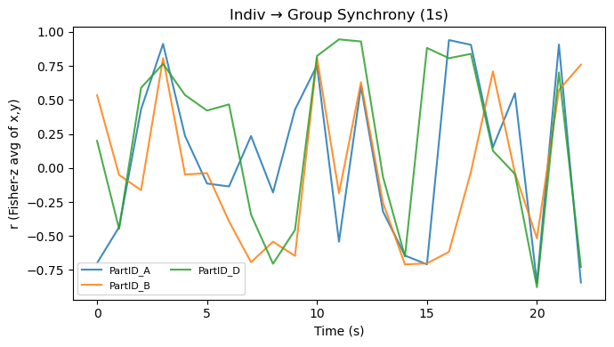

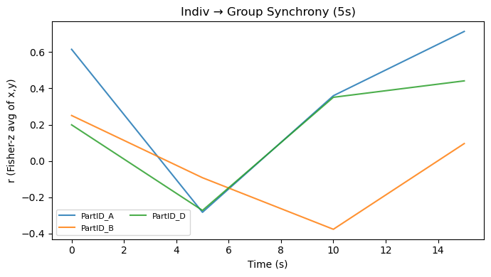

```python
def plot_indiv(window="1s"):
    csv_path = DATA_PROC / "indiv_to_group_sync" / window / "indiv_vs_group_sync.csv"
    dfi = pd.read_csv(csv_path)
    time = dfi["time_s"]
    part_cols = [c for c in dfi.columns if c.startswith("PartID_")]

    plt.figure(figsize=(7, 4))
    for c in part_cols:
        plt.plot(time, dfi[c], alpha=0.85, label=c)
    plt.xlabel("Time (s)")
    plt.ylabel("r (Fisher-z avg of x,y)")
    plt.title(f"Indiv → Group Synchrony ({window})")
    # If legend is too big, comment it out:
    plt.legend(loc="best", ncol=2, fontsize=8)
    plt.tight_layout()
    plt.show()

plot_indiv("1s")
plot_indiv("5s")
```

## 5) Inspect CSV heads

Helpful to sanity-check outputs without opening extra files.

```python
def head(path: Path, n=8):
    if path.exists():
        display(pd.read_csv(path).head(n))
    else:
        print("Missing:", path)

head(p0 / "eye_in_world.csv")
head(DATA_PROC / "pairwise_sync" / "5s" / "pairwise_group_sync.csv")
head(DATA_PROC / "indiv_to_group_sync" / "5s" / "indiv_vs_group_sync.csv")
```

|  | gaze_x_norm | gaze_y_norm | x | y | z |
| --- | --- | --- | --- | --- | --- |
| 0 | -0.103558 | 0.095559 | 250.048062 | -0.044350 | 390.000000 |
| 1 | -0.101000 | 0.076596 | 250.713889 | -0.247854 | 389.999394 |
| 2 | -0.097269 | 0.061431 | 251.546864 | -0.577791 | 389.997269 |
| 3 | -0.107881 | 0.056232 | 252.528987 | -0.994894 | 389.993058 |
| 4 | -0.114976 | 0.053584 | 253.654258 | -1.475347 | 389.986242 |
| 5 | -0.121236 | 0.059240 | 254.919498 | -2.008109 | 389.976329 |
| 6 | -0.120888 | 0.059460 | 256.315697 | -2.589314 | 389.962899 |
| 7 | -0.112156 | 0.057756 | 257.823739 | -3.213218 | 389.945680 |

|  | time_s | PairID_A_B | PairID_A_D | PairID_B_D | GroupAverage |
| --- | --- | --- | --- | --- | --- |
| 0 | 0.0 | 0.615889 | 0.343871 | 0.004176 | 0.304505 |
| 1 | 5.0 | -0.124089 | -0.368025 | -0.102662 | -0.193389 |
| 2 | 10.0 | -0.438827 | 0.688217 | -0.340069 | -0.025570 |
| 3 | 15.0 | 0.356624 | 0.627698 | -0.057391 | 0.303519 |

|  | time_s | PartID_A | PartID_B | PartID_D |
| --- | --- | --- | --- | --- |
| 0 | 0.0 | 0.615329 | 0.250798 | 0.199311 |
| 1 | 5.0 | -0.282325 | -0.091977 | -0.272011 |
| 2 | 10.0 | 0.359720 | -0.375911 | 0.351061 |
| 3 | 15.0 | 0.713823 | 0.096255 | 0.441570 |

**Notes**

- All windows are **non-overlapping** (for independence of samples statistical purposes).
- Pairwise curve per window is the **Fisher-z average** of `(r_x, r_y)`.
- GroupAverage is the mean of all pairwise `r_x` and `r_y` values per window.